# Individual 2

## Number of Ratings per Year

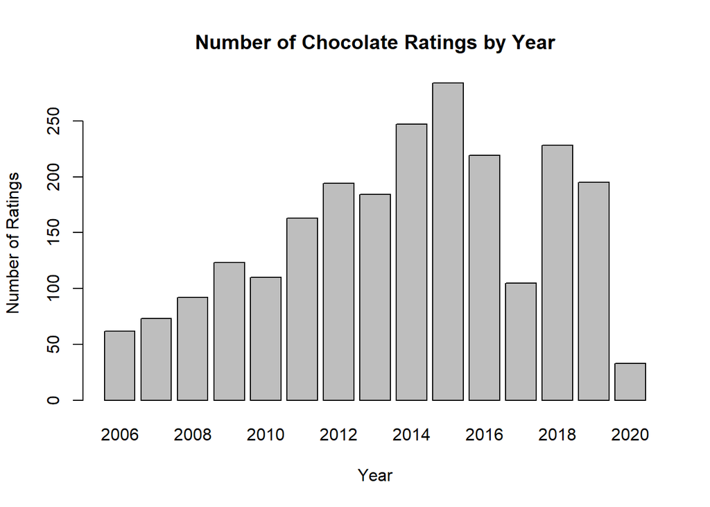

```r
chocoYR <- choco[, c("Date", "Rating")]
myTable <- addmargins(table(chocoYR), 2)
chocos <- as.data.frame(myTable)
chocos2 <- chocos[chocos$Rating == "Sum", c("Date", "Freq")]
barplot(chocos2$Freq, names.arg = chocos2$Date, xlab = "Year", ylab = "Number of Ratings", main = "Number of Chocolate Ratings by Year")
```

There seems to be an upward trend in frequency of ratings from 2006-2015, but then the number of ratings began to significantly decrease. 2020 can be ignored as the year is not complete.

## Ratings Based on Cacao Percentage

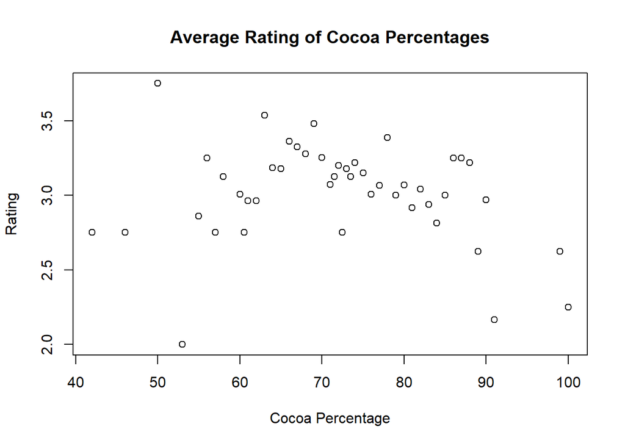

```r
chocoAgg <- aggregate(choco[, "Rating"], FUN = mean, list(choco$Cocoa_Percent))
plot(chocoAgg, ylab = "Rating", xlab= "Cocoa Percentage", main = "Average Rating of Cocoa Percentages")
```

```r
choco2 <- choco[, c("Rating", "Cocoa_Percent")]
chocoTable <- addmargins(table(choco2), 1)
chocos <- as.data.frame(chocoTable)
chocos[chocos$Rating == "Sum", c("Cocoa_Percent","Freq")]
```

```
##     Cocoa_Percent Freq
## 14             42    1
## 28             46    1
## 42             50    1
## 56             53    1
## 70             55   16
## 84             56    2
## 98             57    1
## 112            58    8
## 126            60   46
## 140          60.5    1
## 154            61    7
## 168            62   14
## 182            63   14
## 196            64   34
```

[output cut: 32 more lines]

Notice how chocolates with cocoa percentages of 70, 72, and 75 have vastly more total ratings than any of the other cocoa percentages. This dataset simply is not populated with enough data to find any strong correlation between cocoa percentages and rating.

## Favorable Characteristics

First, we will find the average rating of each category. The most straightforward way to do this is to use the aggregate function on each category separately, leading to the creation of 4 different dataframes.

```r
choco2 <- choco[, c("Characteristics1", "Characteristics2", "Characteristics3", "Characteristics4", "Rating")]
chocoAgg <- aggregate(Rating ~ Characteristics1, data = choco2, FUN=mean)
chocoAgg1 <- chocoAgg[order(chocoAgg$Rating), ]
chocoAgg <- aggregate(Rating ~ Characteristics2, data = choco2, FUN=mean)
chocoAgg2 <- chocoAgg[order(chocoAgg$Rating), ]
chocoAgg <- aggregate(Rating ~ Characteristics3, data = choco2, FUN=mean)
chocoAgg3 <- chocoAgg[order(chocoAgg$Rating), ]
chocoAgg <- aggregate(Rating ~ Characteristics4, data = choco2, FUN=mean)
chocoAgg4 <- chocoAgg[order(chocoAgg$Rating), ]
```

Now we will add a new column to merge the data with.

```r
chocoAgg1["Characteristic"] <- chocoAgg1["Characteristics1"]
chocoAgg2["Characteristic"] <- chocoAgg2["Characteristics2"]
chocoAgg3["Characteristic"] <- chocoAgg3["Characteristics3"]
chocoAgg4["Characteristic"] <- chocoAgg4["Characteristics4"]
```

Now, we will merge all the dataframes together, finding the average rating of each category while we do so.

```r
chocoM <- merge(x = chocoAgg1, y=chocoAgg2, by = "Characteristic", all = T)
chocoM["Rating"] <- rowMeans(chocoM[, c("Rating.x", "Rating.y")], na.rm = TRUE)
chocoM <- chocoM[, c("Characteristic", "Rating")]
chocoM <- merge(x = chocoM, y=chocoAgg3, by = "Characteristic", all = T)
chocoM["Rating"] <- rowMeans(chocoM[, c("Rating.x", "Rating.y")], na.rm = TRUE)
chocoM <- chocoM[, c("Characteristic", "Rating")]
chocoM <- merge(x = chocoM, y=chocoAgg4, by = "Characteristic", all = T)
chocoM["Rating"] <- rowMeans(chocoM[, c("Rating.x", "Rating.y")], na.rm = TRUE)
chocoM <- chocoM[, c("Characteristic", "Rating")]
```

As we seek the best chocolate categories, we can safely filter out categories with an average rating below 3.7. In addition, we will want to avoid categories with average ratings of exactly 3.75 or 4.0 as categories with such scores likely are used rarely.

```r
chocoM <- chocoM[chocoM$Rating > 3.7 & !(chocoM$Rating == 3.75 | chocoM$Rating == 4), ]
chocoM
```

```
##     Characteristic   Rating
## 26        balanced 3.782143
## 195          dense 3.875000
## 381           long 3.739583
## 543         peanut 3.787500
## 579      raspberry 3.833333
## 614         robust 3.708333
## 744         subtle 3.703125
## 842           wine 3.718750
```

Under these restrictions, these 8 categories stand out as the best. Finally, below lies a barplot to visualize the differences between these 8 categories.

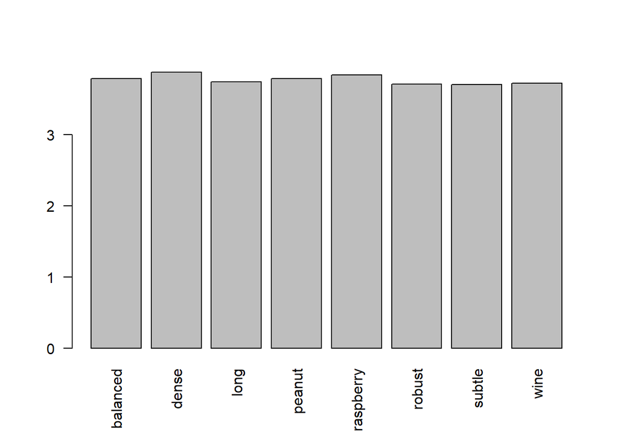

```r
barplot(chocoM$Rating, names.arg = chocoM$Characteristic, las = 2)
```

## Scores Over the Years

First, to see if evaluating how scores have changed over the years makes a valid comparison, we need to check if there is plenty of data to use each year.

```r
chocoYR <- choco[, c("Date", "Rating")]
chocoTable <- addmargins(table(chocoYR), 2)
chocos <- as.data.frame(chocoTable)
chocos[chocos$Rating == "Sum", c("Date", "Freq")]
```

```
##     Date Freq
## 196 2006   62
## 197 2007   73
## 198 2008   92
## 199 2009  123
## 200 2010  110
## 201 2011  163
## 202 2012  194
## 203 2013  184
## 204 2014  247
## 205 2015  284
## 206 2016  219
## 207 2017  105
## 208 2018  228
## 209 2019  195
## 210 2020   33
```

As can be seen by the table above, nearly every year has a plenitude of data. The first point of investigation is whether scoring tendencies have changed over time. We can check this by finding the average score in a year and plotting each average score in a scatterplot. The upcoming chart does this.

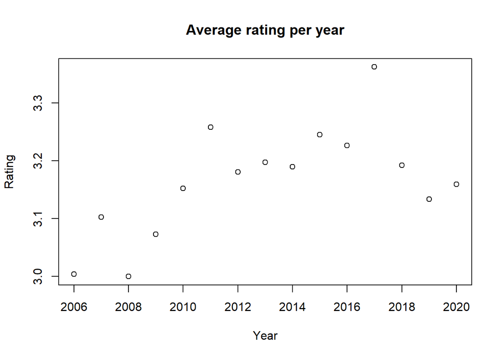

```r
chocoAgg <- aggregate(choco[, "Rating"], FUN = mean, list(choco$Date))
plot(chocoAgg, main="Average rating per year", xlab = "Year", ylab = "Rating")
```